# Lab 2: R Basics

Chang-Hsin Lee

Last modified on January 24, 2016

In this Lab I will show you some R workflow basics, which include saving and loading data, some R object types, subsetting data. We will also learn to make a boxplot. Finally, I will introduce an efficient way to make R programming reports in R Markdown.

## Working directory

To import or export a file from your computer, you need to set R’s working directory to where the file’s location. The `getwd()` functions prints the current working directory

```r
getwd()
```

To set working directory, use the `setwd()` function.

```r
setwd("...")
```

The “…” part defines the target directory path. For example, if I want to set the working directory to `D:/RFiles/Lab2`, use `setwd("D:/RFiles/Lab2")`. Alternatively, you can set the working directory from RStudio.

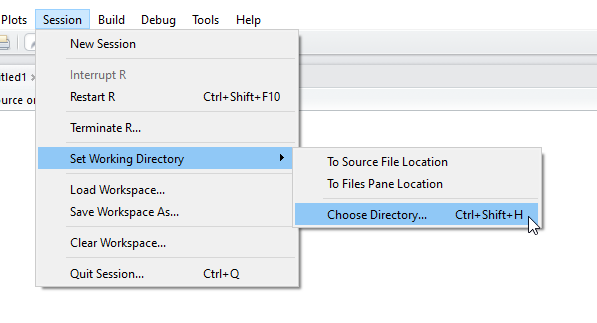

Don’t forget to change the Files pane as well, so you can keep track of what is going on in the folder.

[figure not shown]

## Importing data

Most of the data you will find online are in one of the two formats: .txt or .csv (comma separated values). Once the working directory is set to the file location, we can read the data into R by `read.table()` or `read.csv()`. Here I will demonstrate the process with the `txhousing` data from ggplot2 exported as a .csv file. You can find the .csv file from Blackboard.

```r
data.txhousing <- read.csv("txhousing.csv", header=TRUE, stringsAsFactors=FALSE)
```

A function in R like `read.csv()` can often take multiple argument inputs. Please check help file on `read.csv()`. In this example, the first argument of `read.csv` is `file="txhousing.csv"`. An argument name can be omitted as long as the input arguments position matches the function default. In this case R automatically supply `"txhousing.csv"` to `file`, which is the first argumnent of `read.csv()`. One thing to note is that `file` does not have a default, so it has to be specified each time `read.csv()` is called.

The next argument `header` is defaulted by `header=TRUE`, as can be seen in the help file. Indeed, the following line works just fine.

```r
data.txhousing <- read.csv("txhousing.csv", stringsAsFactors=FALSE)
```

Adding `stringsAsFactors=FALSE` is not required but is recommended. Most R users have ran into a mysterious bug at some point due to the fact that `stringsAsFactors` is defaulted to be `TRUE`. I will show you why when we get to the modeling part.

The .csv file is thus read into R environment as an object named `data.txhousing` with the assignment operator `<-`. You can also use `=` for assignments, but there is a subtle difference between the two. Most of the time using `=` for assignment is not an issue, so just pick one that you prefer and stick to it. RStudio has a keyboard shortcut Alt+ - (minus sign) for inserting `<-`.

## Basic commands

R can be used as a calculator:

```r
1 / 10 * 30
## [1] 3
(29 - 291 + 83) / 32
## [1] -5.59375
exp(2*sin(0.3*pi))
## [1] 5.043166
```

You can save an object by assigning names to to it. For example,

```r
x <- 1 / 10 * 30
y <- (29 - 291 + 83) / 32
x + y
## [1] -2.59375
x * y
## [1] -16.78125
```

Object names can only contain letters, numbers, `_` and, `.`. No dash or space! You can and should name your objects in a more descriptive manner when producing reports.

```r
use_snake_case_convention
orCamelCase
periods.works.too
Dont.Do_somthingLike_this
```

R is also case-sensitive.

```r
a <- 10
A <- 3
a == A
## [1] FALSE
```

Here we see a new operator `==` as an example of logical operators in R. Logical operators compare two objects and output a logical vector with values in `TRUE` and `FALSE`. We will encounter more of them in Lab 3.

## Object types

So far the objects are all single numbers, but there are different objects in R for different purposes. I will go through some common data types and the basic commands associated with them one by one. A good way to check the type of an object is using the `str()` function, which prints out the object type and the first few values. A function that prints less is `class()`, or alternatively `typeof()`.

### Vectors (Numeric/Character/Logical)

A basic one dimensional object in R is a vector. A vector is created with `c()` (combine). Fill in the values and R will choose the data type accordingly.

```r
vec_num <- c(2.5,1/3,sqrt(2),pi,exp(1)) # numeric
vec_chr <- c("character","vector","of","length","5")
vec_logical <- c(TRUE,FALSE,FALSE,TRUE,TRUE)
vec_num
## [1] 2.5000000 0.3333333 1.4142136 3.1415927 2.7182818
vec_chr
## [1] "character" "vector"    "of"        "length"    "5"
vec_logical
## [1]  TRUE FALSE FALSE  TRUE  TRUE
```

Let’s check the class of above vectors with `str()` (structure).

```r
str(vec_num)
##  num [1:5] 2.5 0.333 1.414 3.142 2.718
str(vec_chr)
##  chr [1:5] "character" "vector" "of" "length" "5"
str(vec_logical)
##  logi [1:5] TRUE FALSE FALSE TRUE TRUE
```

We can also form new vectors by combining existing ones with `c()`. However, the data type of the new vector will be coerced to a common type.

```r
c_num_logical <-  c(vec_num,vec_logical)
str(c_num_logical) # Note that TRUE FALSE were converted to 1 and 0, respectively.
##  num [1:10] 2.5 0.333 1.414 3.142 2.718 ...
c_logical_chr <- c(vec_chr,vec_logical)
str(c_logical_chr)
##  chr [1:10] "character" "vector" "of" "length" "5" "TRUE" ...
```

The `length()` function gives you the length of a vector, which can be useful in controlling flow like for loop.

```r
length(vec_num)
## [1] 5
```

To extract (or subset) the values of a vector, specify the location of values by a numeric vector with the extracting operator `[]`. Run `?"["` to read help file on extraction.

```r
vec_num[c(3,1,2)]
## [1] 1.4142136 2.5000000 0.3333333
vec_logical[c(2,1)]
## [1] FALSE  TRUE
```

### Data Frames

Data frame is the bread and butter R object type. A data frame is a list of vectors with headers that share **the same length**. For example, When we load data into R with `read.csv()`, it is stored as a data frame.

```r
str(data.txhousing)
## 'data.frame':    1122 obs. of  11 variables:
##  $ X.1      : int  1 2 3 4 5 6 7 8 9 10 ...
##  $ X        : int  1871 1872 1873 1874 1875 1876 1877 1878 1879 1880 ...
##  $ city     : chr  "Corpus Christi" "Corpus Christi" "Corpus Christi" "Corpus Christi" ...
##  $ year     : int  2000 2000 2000 2000 2000 2000 2000 2000 2000 2000 ...
##  $ month    : int  1 2 3 4 5 6 7 8 9 10 ...
##  $ sales    : int  182 219 351 288 317 339 287 398 307 274 ...
##  $ volume   : num  17665000 20240000 36255000 28915000 34565000 ...
##  $ median   : num  78500 78700 85500 80000 90200 93600 90700 85400 86100 82600 ...
##  $ listings : int  2510 2534 2591 2631 2651 2632 2687 2232 2529 2471 ...
##  $ inventory: num  9.3 9.4 9.4 9.6 9.7 9.6 9.9 8 8.9 8.5 ...
##  $ date     : num  2000 2000 2000 2000 2000 ...
```

To create a data frame from scratch, use `data.frame()`. Let’s use the vectors from before.

```r
newframe <- data.frame(
  width=vec_num,
  description=vec_chr,
  logical=vec_logical)

newframe
##       width description logical
## 1 2.5000000   character    TRUE
## 2 0.3333333      vector   FALSE
## 3 1.4142136          of   FALSE
## 4 3.1415927      length    TRUE
## 5 2.7182818           5    TRUE
```

```r
dim(data.txhousing)
## [1] 1122   11
```

To extract a subset of data frame, use the extracting operator `[]` just like extracting vectors. However, two arguments need to be specified this time as the corresponding row and column number. In the following example, `c(1:5)` creates a vector of integers from 1 to 5. You can also subset the columns by a character string. We will zoom in on data frame manipulations in Lab 3 with the introduction of package dplyr.

```r
data.txhousing[2,2]
## [1] 1872
data.txhousing[c(1000:1005),c(1:5)]  # subset row 1000 to 1005, column 1 to 5.
##       X.1    X        city year month
## 1000 1000 6797 San Antonio 2005     5
## 1001 1001 6798 San Antonio 2005     6
## 1002 1002 6799 San Antonio 2005     7
## 1003 1003 6800 San Antonio 2005     8
## 1004 1004 6801 San Antonio 2005     9
## 1005 1005 6802 San Antonio 2005    10
data.txhousing[c(1000:1005),c("X","city","year","month")]
##         X        city year month
## 1000 6797 San Antonio 2005     5
## 1001 6798 San Antonio 2005     6
## 1002 6799 San Antonio 2005     7
## 1003 6800 San Antonio 2005     8
## 1004 6801 San Antonio 2005     9
## 1005 6802 San Antonio 2005    10
```

Use `$` To extract just one column from a data frame *as a vector*.

```r
data.txhousing$city
```

Be careful when subsetting columns from a data frame. In the following chunk, the first line gives a object whose type is different from the other two, even though the data seem to be the same!

```r
str(data.txhousing["city"])
## 'data.frame':    1122 obs. of  1 variable:
##  $ city: chr  "Corpus Christi" "Corpus Christi" "Corpus Christi" "Corpus Christi" ...
str(data.txhousing[,"city"])
##  chr [1:1122] "Corpus Christi" "Corpus Christi" "Corpus Christi" ...
str(data.txhousing$city)
##  chr [1:1122] "Corpus Christi" "Corpus Christi" "Corpus Christi" ...
```

### Factors

R has a special data type to deal with categorical variables called factors. Factors are variables that have a fixed and known set of values. The most important part of a factor is the *levels* of a factor, which records the possible values it can take and all other values are converted to `NA`. `NA` are missing values and one should always be careful when dealing with them. I will talk more about factors when we get into categorical data analysis. For now just be aware of their existence.

```r
sport <-c("soccer", "basketball", "lacrosse", "soccer", "soccer", "lacrosse")
sport.f <- factor(sport, levels=c("basketball", "soccer", "lacrosse"))
sport.f2 <- factor(sport, levels=c("basketball", "soccer"))
sport
## [1] "soccer"     "basketball" "lacrosse"   "soccer"     "soccer"
## [6] "lacrosse"
sport.f
## [1] soccer     basketball lacrosse   soccer     soccer     lacrosse
## Levels: basketball soccer lacrosse
sport.f2
## [1] soccer     basketball <NA>       soccer     soccer     <NA>
## Levels: basketball soccer
```

## Descriptive statistics

One quick way to quickly summarize a data frame (or a vector) is by passing the data to the `summary()` function, which prints out basic descriptive statistics of its columns.

```r
summary(data.txhousing)
##       X.1               X            city                year
##  Min.   :   1.0   Min.   :1871   Length:1122        Min.   :2000
##  1st Qu.: 281.2   1st Qu.:2151   Class :character   1st Qu.:2003
##  Median : 561.5   Median :3086   Mode  :character   Median :2007
##  Mean   : 561.5   Mean   :3647                      Mean   :2007
##  3rd Qu.: 841.8   3rd Qu.:4769                      3rd Qu.:2011
##  Max.   :1122.0   Max.   :6919                      Max.   :2015
##
##      month            sales            volume              median
##  Min.   : 1.000   Min.   : 110.0   Min.   :1.162e+07   Min.   : 73600
##  1st Qu.: 3.000   1st Qu.: 354.0   1st Qu.:4.789e+07   1st Qu.:111900
##  Median : 6.000   Median : 838.5   Median :1.156e+08   Median :135850
##  Mean   : 6.406   Mean   :2128.5   Mean   :4.210e+08   Mean   :133553
##  3rd Qu.: 9.000   3rd Qu.:3997.8   3rd Qu.:7.553e+08   3rd Qu.:151150
##  Max.   :12.000   Max.   :8945.0   Max.   :2.568e+09   Max.   :242300
##                   NA's   :2        NA's   :2           NA's   :4
##     listings       inventory           date
##  Min.   :  598   Min.   : 1.800   Min.   :2000
##  1st Qu.: 2178   1st Qu.: 4.700   1st Qu.:2004
##  Median : 6662   Median : 5.800   Median :2008
##  Mean   :11542   Mean   : 5.901   Mean   :2008
##  3rd Qu.:19752   3rd Qu.: 6.900   3rd Qu.:2012
##  Max.   :43107   Max.   :12.700   Max.   :2016
##  NA's   :37      NA's   :37
```

We can also compute specific statistics of numeric vectors with built-in functions.

- `mean(x)`: mean of the vector `x`
- `var(x)`: variance of the vector `x`
- `sd(x)`: standard deviation of the vector `x`
- `quantile(x)`: quantiles of the vector `x`

Most of the built-in statistical functions need to throw away NAs (missing values) to run by setting `na.rm=TRUE`. For example, `quantile(data.txhousing$volume)` causes an error but `quantile(data.txhousing$volume, na.rm=TRUE)` does not. Another possibility is having NAs showing up in unwanted places:

```r
mean(data.txhousing$volume)
## [1] NA
mean(data.txhousing$volume, na.rm=TRUE)
## [1] 420991651
```

## Boxplot and violin plot

Boxplot is a widely used plot that can visualize the descriptive statistics shown in the `summary()` call. It is a bivariate graphic created in ggplot2 with the geom `geom_boxplot()`. One advantage of ggplot2 is we can assign the layers to an object, so we can quickly cycle through geom options to find the most suitable one.

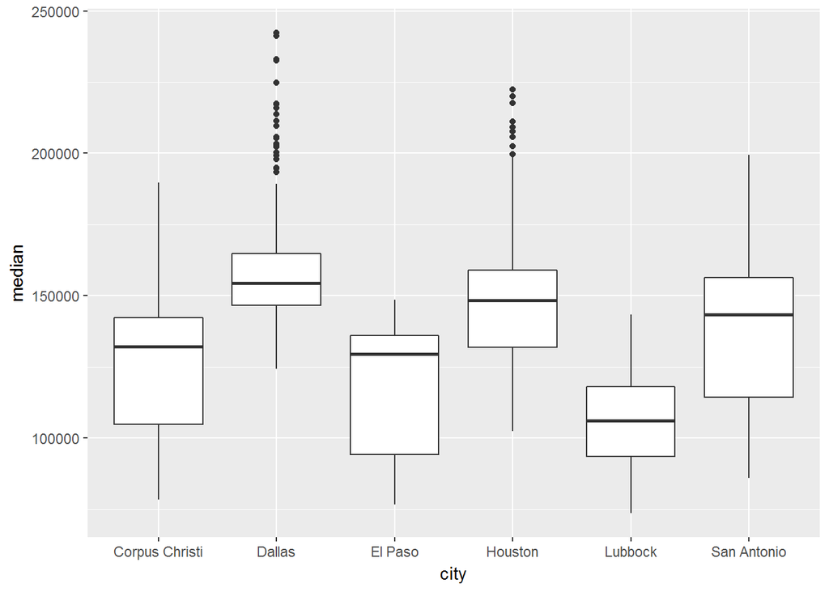

```r
library(ggplot2)
plot.city <- ggplot(data=data.txhousing, aes(x=city, y=median))
plot.city + geom_boxplot()
```

A boxplot is a good way to plot a normally distributed data (bell curve). However, if the data does not look like a bell curve, say it has two peaks, then a good plotting alternative to use is the violin plot. In ggplot2, violin plots uses the geom `geom_violin()`. Because we have saved the first layer of ggplot2 in `plot.city`, we just need to stack a new geom on top of it.

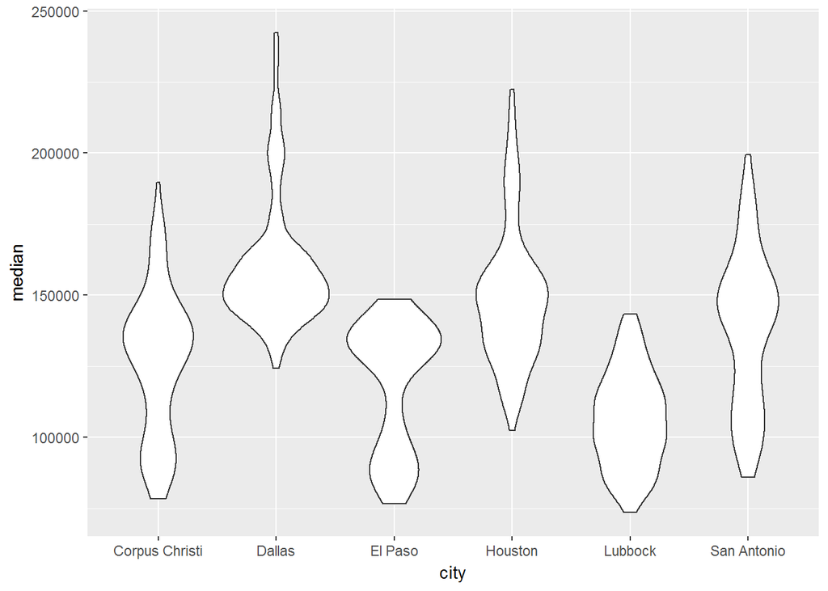

```r
plot.city + geom_violin()
```

## Saving your objects/plots

There are different ways to save objects from R environment. One common apporach is the `save()` function which saves R data into a .RData file. Another useful function is the `saveRDS()`. Please refer to their help files since we will not use them here. I will only demonstrate how to export a data frame into a .csv file and a plot into .png.

```r
write.csv(data.txhousing, file="new_txhousing.csv") # save data.txhousing into a .csv file in working directory

plot.city.violin <- plot.city + geom_violin() # create a ggplot2 object
ggsave("city_violin.png", plot = plot.city.violin)
## Saving 7 x 5 in image
## Warning: Removed 4 rows containing non-finite values (stat_ydensity).
```

## Appendix: R Markdown

Markdown is a widely used text formatting language that has become standard in popular online communities like Reddit, StackExchange, and GitHub. This [video](http://rmarkdown.rstudio.com/lesson-1.html) from RStudio gives an overview for R Markdown. I use R Markdown to typeset all my R notes, and I encourage you to give it a try.

Make sure that you installed the `rmarkdown` package. RStudio has built-in support for Rmarkdown files (.Rmd), and you can create a blank document from the tab.

[figure not shown]

An R Markdown file has three basic sections: Metadata, texts, and code chunks. The metadata controls the overall style and file format of document.

```
---
title: "Lab 2: R Basics"
author: "Chang-Hsin Lee"
date: "September 12, 2016"
output: html_document
  theme: spacelab
---
```

The text part is just regular text, but you can change the format of texts by adding special symbols like * or # in front of a line of text. [Here](http://rmarkdown.rstudio.com/lesson-8.html) is a good example of Markdown basics.

Once you have your document ready, either press the Knit button in RStudio

[figure not shown]

or use the render function from `rmarkdown` package. (Make sure the working directory is correct.)

```r
render("MyFirstMarkdown.Rmd")
```

If you feel I am giving too little instructions on making a Markdown file, start typing something now! The idea behind it is to make typing easy, so it really is not complicated at all, just give it a try. [R Markdown Cheatsheet](http://www.rstudio.com/wp-content/uploads/2016/03/rmarkdown-cheatsheet-2.0.pdf) is an extremely useful reference that will answer most of your Markdown questions.

R Markdown can produce presentation slides in .html format. If you want to create a .pdf file (not recommended) instead of .html, you will also need to install [LaTex](http://miktex.org/) and [Pandoc](http://pandoc.org/) then put `output: pdf_document` in the header.